# mpdw praktikum

MARESKA RADELA PUTRA

2025-08-29

# Packages

```r
library("forecast")
```

```r
library("graphics")
library("TTR")
library("TSA")
```

# Data

```r
library(readxl)
data <- read_xlsx("C:/Users/Mareska Radela Putra/Downloads/MPDW Separated.xlsx")
data
```

```
## # A tibble: 259 × 2
##    Date                Close
##    <dttm>              <dbl>
##  1 2005-08-22 00:00:00 1049.
##  2 2005-08-29 00:00:00 1039.
##  3 2005-09-05 00:00:00 1098.
##  4 2005-09-12 00:00:00 1057.
##  5 2005-09-19 00:00:00 1013.
##  6 2005-09-26 00:00:00 1079.
##  7 2005-10-03 00:00:00 1095.
##  8 2005-10-10 00:00:00 1097.
##  9 2005-10-17 00:00:00 1076.
## 10 2005-10-24 00:00:00 1058.
## # ℹ 249 more rows
```

# Eksplorasi Data

## Melihat tipe data

```r
View(data)
str(data)
```

```
## tibble [259 × 2] (S3: tbl_df/tbl/data.frame)
##  $ Date : POSIXct[1:259], format: "2005-08-22" "2005-08-29" ...
##  $ Close: num [1:259] 1049 1039 1098 1057 1013 ...
```

```r
dim(data)
```

```
## [1] 259   2
```

## Mengubah data agar terbaca sebagai data deret waktu dengan fungsi `ts()`

```r
data.ts <- ts(data$Close)
```

## Menampilkan ringkasan data

```r
summary(data.ts)
```

```
##    Min. 1st Qu.  Median    Mean 3rd Qu.    Max.
##    1013    1386    2033    1974    2472    3069
```

## Membuat plot data deret waktu

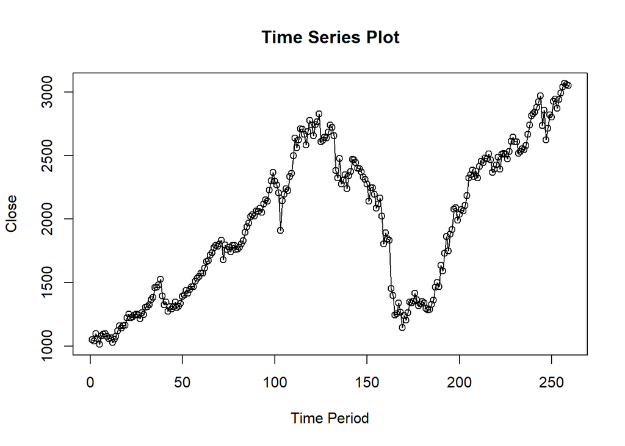

```r
ts.plot(data.ts, xlab="Time Period", ylab="Close",
        main = "Time Series Plot")
points(data.ts)
```

# Pembagian Data

```r
training_ma <- data[1:231,]
testing_ma <- data[232:259,]

train_ma.ts <- ts(training_ma$Close)
test_ma.ts  <- ts(testing_ma$Close)
```

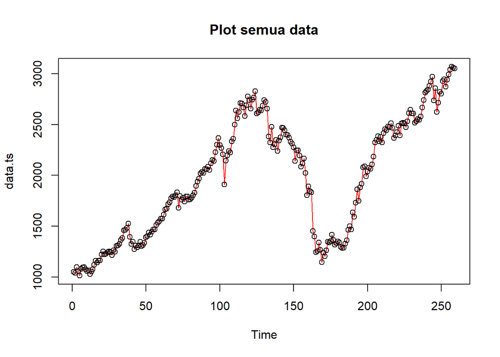

```r
#eksplorasi keseluruhan data
plot(data.ts, col="red",main="Plot semua data")
points(data.ts)
```

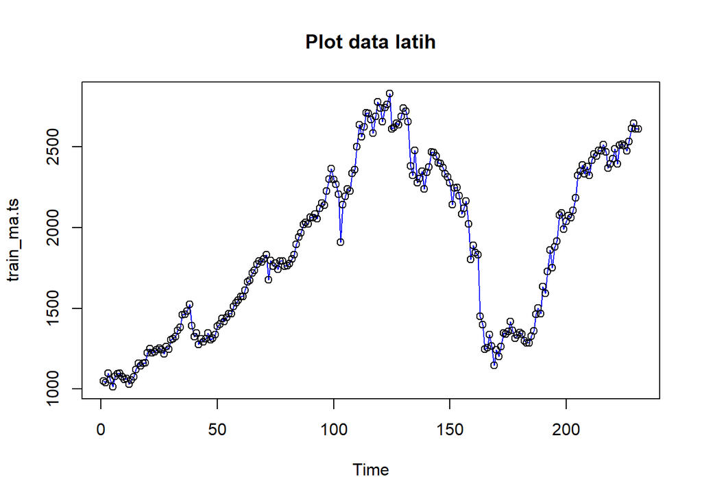

```r
#eksplorasi data latih
plot(train_ma.ts, col="blue",main="Plot data latih")
points(train_ma.ts)
```

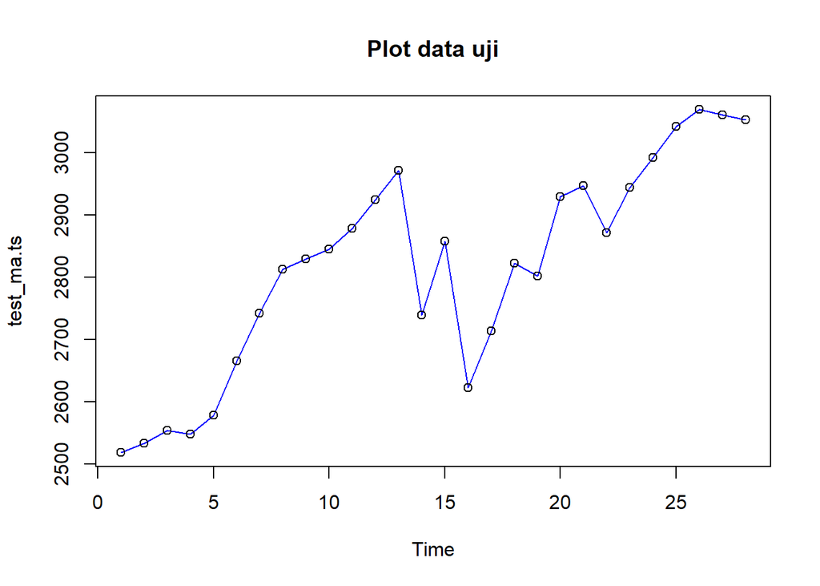

```r
#eksplorasi data uji
plot(test_ma.ts, col="blue",main="Plot data uji")
points(test_ma.ts)
```

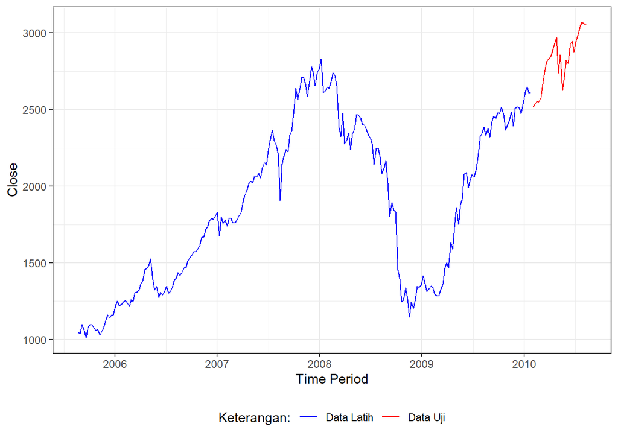

```r
library(ggplot2)
ggplot() +
  geom_line(data = training_ma, aes(x = Date, y = Close, col = "Data Latih")) +
  geom_line(data = testing_ma, aes(x = Date, y = Close, col = "Data Uji")) +
  labs(x = "Time Period", y = "Close", color = "Legend") +
   scale_colour_manual(name="Keterangan:", breaks = c("Data Latih", "Data Uji"),
                      values = c("blue", "red")) +
  theme_bw() + theme(legend.position = "bottom",
                     plot.caption = element_text(hjust=0.5, size=12))
```

# Metode Pemulusan

## Single Moving Average (SMA)

```r
data.sma<-SMA(train_ma.ts, n=4)
data.sma
```

```
## Time Series:
## Start = 1
## End = 231
## Frequency = 1
##   [1]       NA       NA       NA 1060.780 1051.775 1061.786 1060.835 1070.829
##   [9] 1086.606 1081.351 1073.927 1056.998 1051.754 1055.789 1069.405 1102.175
##  [17] 1124.284 1145.268 1156.072 1171.616 1198.366 1214.503 1231.271 1236.740
##  [25] 1237.409 1242.555 1239.163 1243.448 1242.027 1257.452 1281.260 1296.687
##  [33] 1325.654 1344.890 1381.867 1417.223 1447.163 1483.076 1466.502 1431.189
##  [41] 1397.346 1334.592 1313.727 1305.481 1296.126 1314.413 1312.928 1319.031
##  [49] 1325.818 1336.179 1360.830 1391.626 1411.506 1425.289 1441.385 1448.368
##  [57] 1471.841 1494.371 1515.134 1541.757 1557.261 1576.838 1605.638 1630.615
##  [65] 1666.835 1697.290 1724.901 1754.914 1771.921 1789.613 1803.929 1775.400
##  [73] 1777.850 1766.271 1753.229 1768.797 1768.498 1776.584 1771.494 1777.560
##  [81] 1773.442 1777.044 1794.769 1827.525 1868.339 1909.030 1956.216 1990.654
```

[output cut: 18 more lines]

```r
data.ramal<-c(NA,data.sma)
data.ramal #forecast 1 periode ke depan
```

```
##   [1]       NA       NA       NA       NA 1060.780 1051.775 1061.786 1060.835
##   [9] 1070.829 1086.606 1081.351 1073.927 1056.998 1051.754 1055.789 1069.405
##  [17] 1102.175 1124.284 1145.268 1156.072 1171.616 1198.366 1214.503 1231.271
##  [25] 1236.740 1237.409 1242.555 1239.163 1243.448 1242.027 1257.452 1281.260
##  [33] 1296.687 1325.654 1344.890 1381.867 1417.223 1447.163 1483.076 1466.502
##  [41] 1431.189 1397.346 1334.592 1313.727 1305.481 1296.126 1314.413 1312.928
##  [49] 1319.031 1325.818 1336.179 1360.830 1391.626 1411.506 1425.289 1441.385
##  [57] 1448.368 1471.841 1494.371 1515.134 1541.757 1557.261 1576.838 1605.638
##  [65] 1630.615 1666.835 1697.290 1724.901 1754.914 1771.921 1789.613 1803.929
##  [73] 1775.400 1777.850 1766.271 1753.229 1768.797 1768.498 1776.584 1771.494
##  [81] 1777.560 1773.442 1777.044 1794.769 1827.525 1868.339 1909.030 1956.216
##  [89] 1990.654 2010.940 2034.697 2044.886 2057.624 2065.662 2079.881 2102.852
##  [97] 2116.590 2159.738 2204.977 2258.494 2298.276 2308.961 2285.410 2170.975
## [105] 2132.150 2113.287 2121.413 2200.653 2248.746 2289.961 2355.129 2458.276
## [113] 2515.340 2581.644 2634.151 2651.514 2677.751 2667.730 2662.159 2679.978
## [121] 2697.817 2716.224 2730.596 2727.157 2749.707 2737.996 2706.664 2677.073
## [129] 2629.281 2648.545 2678.716 2697.496 2701.838 2625.648 2521.248 2460.161
## [137] 2365.322 2345.450 2351.876 2292.626 2309.044 2326.818 2356.710 2413.052
## [145] 2438.448 2445.250 2427.645 2404.101 2376.044 2354.173 2323.783 2266.125
## [153] 2244.433 2227.934 2207.703 2193.707 2162.495 2141.794 2098.455 2028.186
## [161] 1970.999 1891.039 1843.526 1755.431 1632.359 1482.058 1338.113 1309.787
## [169] 1276.027 1251.380 1247.590 1213.587 1213.235 1263.735 1288.572 1326.837
## [177] 1365.261 1369.158 1362.832 1357.147 1340.640 1334.357 1329.696 1317.899
## [185] 1301.913 1299.086 1315.073 1359.388 1412.803 1447.380 1515.852 1547.999
## [193] 1605.302 1704.494 1733.524 1806.114 1852.924 1907.022 1992.026 2019.216
## [201] 2050.055 2049.148 2042.186 2071.155 2107.519 2169.500 2241.007 2311.132
## [209] 2348.191 2361.694 2355.095 2362.365 2393.136 2409.969 2449.246 2463.859
## [217] 2478.563 2484.404 2456.368 2436.545 2414.295 2419.149 2425.603 2454.712
## [225] 2477.786 2483.338 2503.678 2509.381 2533.198 2567.575 2601.438 2620.547
```

```r
data.gab<-cbind(
  aktual=c(data.ts),
  pemulusan=c(data.sma,rep(NA,28)),
  ramalan=c(data.ramal,rep(data.ramal[length(data.ramal)],27)))

data.gab #forecast 28 periode ke depan
```

```
##          aktual pemulusan  ramalan
##   [1,] 1048.833        NA       NA
##   [2,] 1039.189        NA       NA
##   [3,] 1098.413        NA       NA
##   [4,] 1056.685  1060.780       NA
##   [5,] 1012.812  1051.775 1060.780
##   [6,] 1079.233  1061.786 1051.775
##   [7,] 1094.609  1060.835 1061.786
##   [8,] 1096.661  1070.829 1060.835
##   [9,] 1075.920  1086.606 1070.829
##  [10,] 1058.215  1081.351 1086.606
##  [11,] 1064.911  1073.927 1081.351
##  [12,] 1028.944  1056.998 1073.927
##  [13,] 1054.944  1051.754 1056.998
##  [14,] 1074.358  1055.789 1051.754
```

[output cut: 245 more lines]

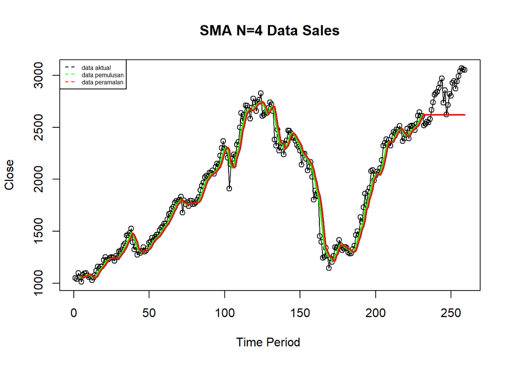

```r
ts.plot(data.ts, xlab="Time Period ", ylab="Close", main= "SMA N=4 Data Sales")
points(data.ts)
lines(data.gab[,2],col="green",lwd=2)
lines(data.gab[,3],col="red",lwd=2)
legend("topleft",c("data aktual","data pemulusan","data peramalan"), lty=8, col=c("black","green","red"), cex=0.5)
```

### SSE, MSE, DAN MAPE

```r
#Menghitung nilai keakuratan data latih
error_train.sma = train_ma.ts-data.ramal[1:length(train_ma.ts)]

SSE_train.sma = sum(error_train.sma[5:length(train_ma.ts)]^2)
MSE_train.sma = mean(error_train.sma[5:length(train_ma.ts)]^2)
MAPE_train.sma = mean(abs((error_train.sma[5:length(train_ma.ts)]/train_ma.ts[5:length(train_ma.ts)])*100))

akurasi_train.sma <- matrix(c(SSE_train.sma, MSE_train.sma, MAPE_train.sma))
row.names(akurasi_train.sma)<- c("SSE", "MSE", "MAPE")
colnames(akurasi_train.sma) <- c("Akurasi m = 4")
akurasi_train.sma
```

```
##      Akurasi m = 4
## SSE   2.409903e+06
## MSE   1.061631e+04
## MAPE  4.105842e+00
```

Dalam hal ini nilai MAPE data latih pada metode pemulusan SMA sekitar 4,11%, nilai ini dapat dikategorikan sebagai nilai akurasi yang sangat baik. Selanjutnya dilakukan perhitungan nilai MAPE data uji pada metode pemulusan SMA.

```r
#Menghitung nilai keakuratan data uji
error_test.sma = test_ma.ts-data.gab[232:259,3]

SSE_test.sma = sum(error_test.sma^2)
MSE_test.sma = mean(error_test.sma^2)
MAPE_test.sma = mean(abs((error_test.sma/test_ma.ts*100)))

akurasi_test.sma <- matrix(c(SSE_test.sma, MSE_test.sma, MAPE_test.sma))
row.names(akurasi_test.sma)<- c("SSE", "MSE", "MAPE")
colnames(akurasi_test.sma) <- c("Akurasi m = 4")
akurasi_test.sma
```

```
##      Akurasi m = 4
## SSE   1.879337e+06
## MSE   6.711917e+04
## MAPE  7.662104e+00
```

## Double Moving Average (DMA)

Metode pemulusan Double Moving Average (DMA) pada dasarnya mirip dengan SMA. Namun demikian, metode ini lebih cocok digunakan untuk pola data trend. Proses pemulusan dengan rata rata dalam metode ini dilakukan sebanyak 2 kali.

```r
dma <- SMA(data.sma, n = 4)
At <- 2*data.sma - dma
Bt <- 2/(4-1)*(data.sma - dma)
data.dma<- At+Bt
data.ramal2<- c(NA, data.dma)

t = 1:28
f = c()

for (i in t) {
  f[i] = At[length(At)] + Bt[length(Bt)]*(i)
}

data.gab2 <- cbind(aktual = c(data.ts),
                   pemulusan1 = c(data.sma,rep(NA,28)),
                   pemulusan2 = c(dma, rep(NA,28)),
                   At = c(At, rep(NA,28)),
                   Bt = c(Bt,rep(NA,28)),
                   ramalan = c(data.ramal2, f[-1]))
data.gab2
```

```
##          aktual pemulusan1 pemulusan2       At           Bt   ramalan
##   [1,] 1048.833         NA         NA       NA           NA        NA
##   [2,] 1039.189         NA         NA       NA           NA        NA
##   [3,] 1098.413         NA         NA       NA           NA        NA
##   [4,] 1056.685   1060.780         NA       NA           NA        NA
##   [5,] 1012.812   1051.775         NA       NA           NA        NA
##   [6,] 1079.233   1061.786         NA       NA           NA        NA
##   [7,] 1094.609   1060.835   1058.794 1062.875    1.3605423        NA
##   [8,] 1096.661   1070.829   1061.306 1080.352    6.3485107 1064.2360
##   [9,] 1075.920   1086.606   1070.014 1103.198   11.0614293 1086.7000
##  [10,] 1058.215   1081.351   1074.905 1087.798    4.2974548 1114.2595
##  [11,] 1064.911   1073.927   1078.178 1069.676   -2.8342107 1092.0950
##  [12,] 1028.944   1056.998   1074.720 1039.275  -11.8152466 1066.8414
##  [13,] 1054.944   1051.754   1066.007 1037.500   -9.5025482 1027.4594
##  [14,] 1074.358   1055.789   1059.617 1051.962   -2.5516307 1027.9971
```

[output cut: 245 more lines]

Hasil pemulusan menggunakan metode DMA divisualisasikan sebagai berikut

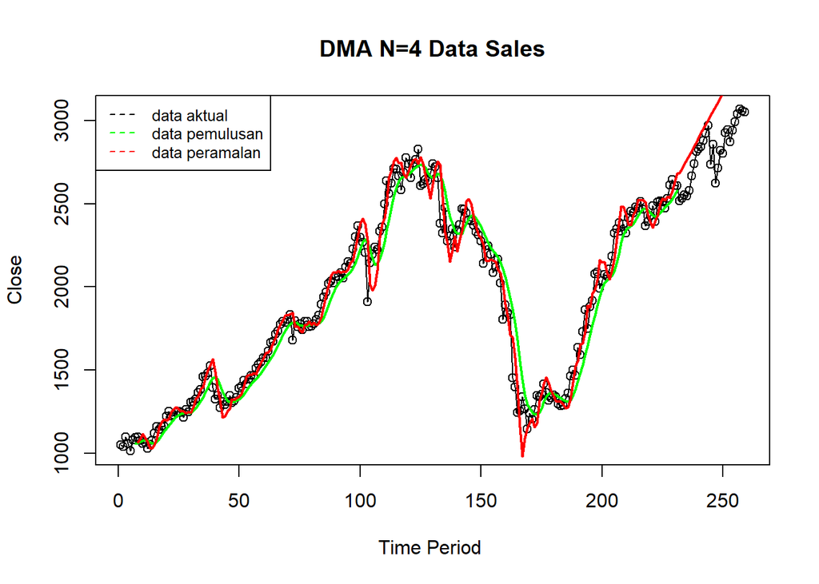

```r
ts.plot(data.ts, xlab="Time Period ", ylab="Close", main= "DMA N=4 Data Sales")
points(data.ts)
lines(data.gab2[,3],col="green",lwd=2)
lines(data.gab2[,6],col="red",lwd=2)
legend("topleft",c("data aktual","data pemulusan","data peramalan"), lty=8, col=c("black","green","red"), cex=0.8)
```

### SSE, MSE, MAPE

```r
#Menghitung nilai keakuratan data latih
error_train.dma = train_ma.ts-data.ramal2[1:length(train_ma.ts)]

SSE_train.dma = sum(error_train.dma[8:length(train_ma.ts)]^2)
MSE_train.dma = mean(error_train.dma[8:length(train_ma.ts)]^2)
MAPE_train.dma = mean(abs((error_train.dma[8:length(train_ma.ts)]/train_ma.ts[8:length(train_ma.ts)])*100))

akurasi_train.dma <- matrix(c(SSE_train.dma, MSE_train.dma, MAPE_train.dma))
row.names(akurasi_train.dma)<- c("SSE", "MSE", "MAPE")
colnames(akurasi_train.dma) <- c("Akurasi m = 4")
akurasi_train.dma
```

```
##      Akurasi m = 4
## SSE   1.823521e+06
## MSE   8.140720e+03
## MAPE  3.498636e+00
```

Perhitungan akurasi pada data latih menggunakan nilai MAPE menghasilkan nilai MAPE yang kurang dari 10%, yaitu 3,50% sehingga dikategorikan sangat baik. Selanjutnya, perhitungan nilai akurasi dilakukan pada data uji.

```r
#Menghitung nilai keakuratan data uji
error_test.dma = test_ma.ts-data.gab2[232:259,6]
SSE_test.dma = sum(error_test.dma^2)
MSE_test.dma = mean(error_test.dma^2)
MAPE_test.dma = mean(abs((error_test.dma/test_ma.ts*100)))

akurasi_test.dma <- matrix(c(SSE_test.dma, MSE_test.dma, MAPE_test.dma))
row.names(akurasi_test.dma)<- c("SSE", "MSE", "MAPE")
colnames(akurasi_test.dma) <- c("Akurasi m = 4")
akurasi_test.dma
```

```
##      Akurasi m = 4
## SSE   1.844805e+06
## MSE   6.588590e+04
## MAPE  8.127730e+00
```

## Pembagian Data SES dan DES

```r
#membagi training dan testing
training<-data[1:231,]
testing<-data[232:259,]
train.ts <- ts(training$Close)
test.ts <- ts(testing$Close)
```

## Single Exponential Smoothing

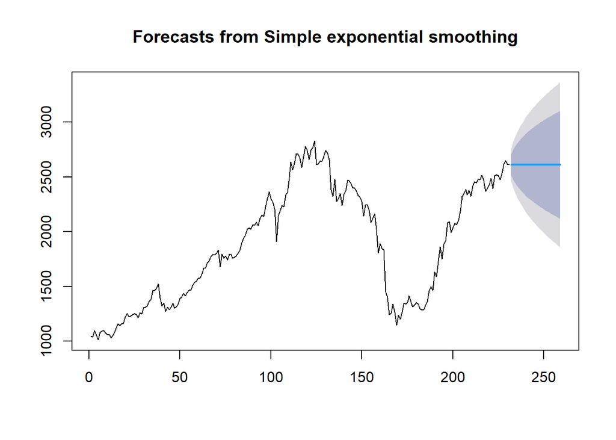

```r
#SES
ses.opt <- ses(train.ts, h = 28, alpha = NULL)
plot(ses.opt)
```

```r
ses.opt
```

```
##     Point Forecast    Lo 80    Hi 80    Lo 95    Hi 95
## 232       2610.738 2513.892 2707.584 2462.625 2758.851
## 233       2610.738 2476.638 2744.838 2405.650 2815.826
## 234       2610.738 2447.684 2773.791 2361.369 2860.107
## 235       2610.738 2423.147 2798.328 2323.843 2897.633
## 236       2610.738 2401.468 2820.008 2290.687 2930.789
## 237       2610.738 2381.833 2839.643 2260.658 2960.818
## 238       2610.738 2363.754 2857.722 2233.008 2988.468
## 239       2610.738 2346.910 2874.565 2207.248 3014.227
## 240       2610.738 2331.080 2890.396 2183.038 3038.438
## 241       2610.738 2316.098 2905.377 2160.126 3061.350
## 242       2610.738 2301.843 2919.633 2138.324 3083.152
## 243       2610.738 2288.217 2933.259 2117.485 3103.991
## 244       2610.738 2275.144 2946.332 2097.491 3123.985
## 245       2610.738 2262.561 2958.915 2078.247 3143.229
## 246       2610.738 2250.417 2971.058 2059.675 3161.801
## 247       2610.738 2238.670 2982.806 2041.709 3179.767
## 248       2610.738 2227.282 2994.194 2024.293 3197.183
## 249       2610.738 2216.223 3005.253 2007.379 3214.096
## 250       2610.738 2205.466 3016.010 1990.927 3230.548
## 251       2610.738 2194.986 3026.489 1974.901 3246.575
## 252       2610.738 2184.765 3036.711 1959.268 3262.208
## 253       2610.738 2174.783 3046.693 1944.002 3277.474
## 254       2610.738 2165.024 3056.451 1929.078 3292.398
## 255       2610.738 2155.475 3066.001 1914.474 3307.002
## 256       2610.738 2146.122 3075.354 1900.169 3321.306
## 257       2610.738 2136.954 3084.522 1886.147 3335.328
## 258       2610.738 2127.959 3093.517 1872.392 3349.084
## 259       2610.738 2119.129 3102.346 1858.887 3362.588
```

```r
#ramalan
ramalanopt<- forecast(ses.opt, h=28)
ramalanopt
```

```
##     Point Forecast    Lo 80    Hi 80    Lo 95    Hi 95
## 232       2610.738 2513.892 2707.584 2462.625 2758.851
## 233       2610.738 2476.638 2744.838 2405.650 2815.826
## 234       2610.738 2447.684 2773.791 2361.369 2860.107
## 235       2610.738 2423.147 2798.328 2323.843 2897.633
## 236       2610.738 2401.468 2820.008 2290.687 2930.789
## 237       2610.738 2381.833 2839.643 2260.658 2960.818
## 238       2610.738 2363.754 2857.722 2233.008 2988.468
## 239       2610.738 2346.910 2874.565 2207.248 3014.227
## 240       2610.738 2331.080 2890.396 2183.038 3038.438
## 241       2610.738 2316.098 2905.377 2160.126 3061.350
## 242       2610.738 2301.843 2919.633 2138.324 3083.152
## 243       2610.738 2288.217 2933.259 2117.485 3103.991
## 244       2610.738 2275.144 2946.332 2097.491 3123.985
## 245       2610.738 2262.561 2958.915 2078.247 3143.229
## 246       2610.738 2250.417 2971.058 2059.675 3161.801
## 247       2610.738 2238.670 2982.806 2041.709 3179.767
## 248       2610.738 2227.282 2994.194 2024.293 3197.183
## 249       2610.738 2216.223 3005.253 2007.379 3214.096
## 250       2610.738 2205.466 3016.010 1990.927 3230.548
## 251       2610.738 2194.986 3026.489 1974.901 3246.575
## 252       2610.738 2184.765 3036.711 1959.268 3262.208
## 253       2610.738 2174.783 3046.693 1944.002 3277.474
## 254       2610.738 2165.024 3056.451 1929.078 3292.398
## 255       2610.738 2155.475 3066.001 1914.474 3307.002
## 256       2610.738 2146.122 3075.354 1900.169 3321.306
## 257       2610.738 2136.954 3084.522 1886.147 3335.328
## 258       2610.738 2127.959 3093.517 1872.392 3349.084
## 259       2610.738 2119.129 3102.346 1858.887 3362.588
```

### Akurasi Data Latih

```r
fitted_train <- fitted(ses.opt)

# Menghitung error data latih
error_train <- train.ts - fitted_train

# SSE, MSE, RMSE, dan MAPE untuk data latih
SSE_train <- sum(error_train^2)
MSE_train <- SSE_train / length(train.ts)
RMSE_train <- sqrt(MSE_train)
MAPE_train <- mean(abs(error_train / train.ts)) * 100

akurasi_latih <- data.frame(
  Dataset = "Data Latih",
  SSE = SSE_train,
  MSE = MSE_train,
  RMSE = RMSE_train,
  MAPE = MAPE_train
)

print(akurasi_latih)
```

```
##      Dataset     SSE      MSE    RMSE     MAPE
## 1 Data Latih 1307746 5661.238 75.2412 2.909369
```

Perhitungan akurasi menggunakan data latih menghasilkan nilai MAPE yang kurang dari 10%, yaitu 2,91% sehingga nilai akurasi ini dapat dikategorikan sebagai sangat baik.

### Akurasi Data Uji

```r
error_test <- ramalanopt$mean - testing$Close

SSE_test <- sum(error_test^2)
MSE_test <- SSE_test / length(test.ts)
RMSE_test <- sqrt(MSE_test)
MAPE_test <- mean(abs(error_test / testing$Close)) * 100

akurasi_uji <- data.frame(
  Dataset = "Data Uji",
  SSE = SSE_test,
  MSE = MSE_test,
  RMSE = RMSE_test,
  MAPE = MAPE_test
)

print(akurasi_uji)
```

```
##    Dataset     SSE      MSE     RMSE     MAPE
## 1 Data Uji 1989904 71067.99 266.5858 7.874056
```

## Double Exponential Smoothing (DES)

```r
des.opt<- HoltWinters(train.ts, gamma = FALSE)
des.opt
```

```
## Holt-Winters exponential smoothing with trend and without seasonal component.
##
## Call:
## HoltWinters(x = train.ts, gamma = FALSE)
##
## Smoothing parameters:
##  alpha: 0.8796594
##  beta : 0.07286502
##  gamma: FALSE
##
## Coefficients:
##         [,1]
## a 2613.47369
## b   15.50441
```

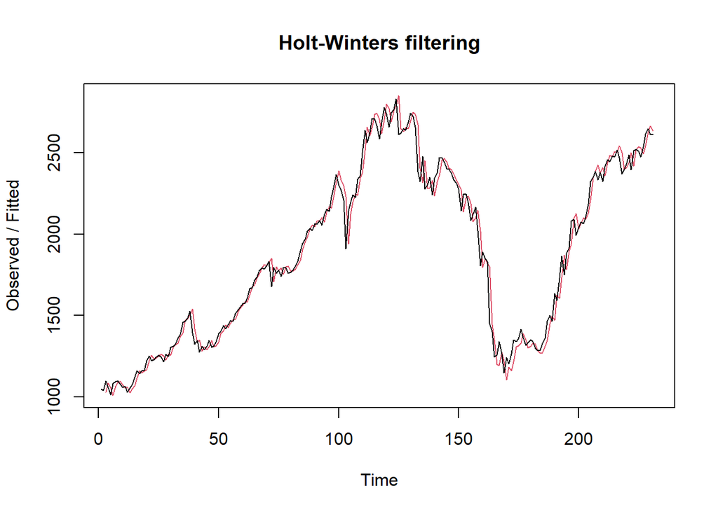

```r
plot(des.opt)
```

```r
#ramalan
ramalandesopt<- forecast(des.opt, h=28)
ramalandesopt
```

```
##     Point Forecast    Lo 80    Hi 80    Lo 95    Hi 95
## 232       2628.978 2532.342 2725.614 2481.186 2776.770
## 233       2644.483 2511.607 2777.358 2441.266 2847.699
## 234       2659.987 2495.239 2824.734 2408.027 2911.946
## 235       2675.491 2480.883 2870.099 2377.864 2973.119
## 236       2690.996 2467.558 2914.434 2349.277 3032.715
## 237       2706.500 2454.756 2958.244 2321.491 3091.510
## 238       2722.005 2442.182 3001.827 2294.053 3149.956
## 239       2737.509 2429.648 3045.370 2266.677 3208.341
## 240       2753.013 2417.031 3088.996 2239.173 3266.854
## 241       2768.518 2404.244 3132.792 2211.409 3325.627
## 242       2784.022 2391.226 3176.818 2183.292 3384.752
## 243       2799.527 2377.933 3221.120 2154.755 3444.298
## 244       2815.031 2364.333 3265.729 2125.748 3504.314
## 245       2830.535 2350.402 3310.669 2096.235 3564.836
## 246       2846.040 2336.121 3355.958 2066.187 3625.893
## 247       2861.544 2321.478 3401.610 2035.585 3687.504
## 248       2877.049 2306.463 3447.634 2004.413 3749.684
## 249       2892.553 2291.069 3494.038 1972.662 3812.444
## 250       2908.058 2275.289 3540.826 1940.322 3875.793
## 251       2923.562 2259.123 3588.001 1907.390 3939.734
## 252       2939.066 2242.566 3635.567 1873.860 4004.272
## 253       2954.571 2225.617 3683.524 1839.733 4069.409
## 254       2970.075 2208.278 3731.873 1805.006 4135.144
## 255       2985.580 2190.547 3780.613 1769.681 4201.478
## 256       3001.084 2172.425 3829.743 1733.759 4268.409
## 257       3016.588 2153.914 3879.263 1697.242 4335.935
## 258       3032.093 2135.015 3929.170 1660.131 4404.054
## 259       3047.597 2115.731 3979.464 1622.430 4472.764
```

### Akurasi Data Latih

```r
SSEdes_train_opt <- des.opt$SSE
MSEdes_train_opt <- SSEdes_train_opt / length(train.ts)

# Ambil residual untuk hitung MAPE
sisaandes_opt <- residuals(des.opt)
MAPEdes_train_opt <- mean(abs(sisaandes_opt / train.ts) * 100, na.rm = TRUE)

# Simpan ke tabel akurasi training
akurasi_des_train_opt <- data.frame(
  Model = "DES Optimal",
  SSE   = SSEdes_train_opt,
  MSE   = MSEdes_train_opt,
  MAPE  = MAPEdes_train_opt
)

print(akurasi_des_train_opt)
```

```
##         Model     SSE      MSE     MAPE
## 1 DES Optimal 1297071 5615.024 2.869743
```

Perhitungan akurasi menggunakan data latih menghasilkan nilai MAPE yang kurang dari 10%, yaitu 2,87% sehingga nilai akurasi ini dapat dikategorikan sebagai sangat baik.

### Akurasi Data Uji

```r
# Hitung selisih antara hasil ramalan DES optimal dan data testing aktual
selisih_des_opt <- ramalandesopt$mean - testing$Close

# Hitung SSE, MSE, dan MAPE untuk data testing
SSEdes_test_opt <- sum(selisih_des_opt^2, na.rm = TRUE)
MSEdes_test_opt <- SSEdes_test_opt / length(testing$Close)
MAPEdes_test_opt <- mean(abs(selisih_des_opt / testing$Close) * 100, na.rm = TRUE)

# Simpan hasil akurasi testing ke dalam tabel
akurasi_des_test_opt <- data.frame(
  Model = "DES Optimal",
  SSE   = SSEdes_test_opt,
  MSE   = MSEdes_test_opt,
  MAPE  = MAPEdes_test_opt
)

# Tampilkan tabel akurasi data testing
print(akurasi_des_test_opt)
```

```
##         Model      SSE      MSE     MAPE
## 1 DES Optimal 253659.2 9059.257 2.825257
```

Berdasarkan MAPE tersebut, model DES lebih baik dibandingkan SES

# Kesimpulan

```r
mape.sma.train <- MAPE_train.sma
mape.sma.test  <- MAPE_test.sma

mape.dma.train <- MAPE_train.dma
mape.dma.test  <- MAPE_test.dma

mape.ses.train <- MAPE_train
mape.ses.test  <- MAPE_test

mape.des.train <- MAPEdes_train_opt
mape.des.test  <- MAPEdes_test_opt
```

```r
rangkuman_mape <- data.frame(
  Model      = c("SMA", "DMA", "SES", "DES"),
  MAPE_Latih = c(mape.sma.train, mape.dma.train, mape.ses.train, mape.des.train),
  MAPE_Uji   = c(mape.sma.test, mape.dma.test, mape.ses.test, mape.des.test)
)

print(rangkuman_mape)
```

```
##   Model MAPE_Latih MAPE_Uji
## 1   SMA   4.105842 7.662104
## 2   DMA   3.498636 8.127730
## 3   SES   2.909369 7.874056
## 4   DES   2.869743 2.825257
```

Berdasarkan hasil perhitungan akurasi yang telah dilakukan menggunakan empat metode, yaitu Single Moving Average (SMA), Double Moving Average (DMA), Single Exponential Smoothing (SES), dan Double Exponential Smoothing (DES), diperoleh nilai MAPE baik pada data latih maupun data uji. Hasil perbandingan menunjukkan bahwa pada data latih, metode DES menghasilkan nilai MAPE paling kecil, yaitu sekitar 2,87%, diikuti oleh SES dengan nilai MAPE 2,91%, kemudian DMA sebesar 3,50%, dan terakhir SMA sebesar 4,11%. Hal ini menunjukkan bahwa untuk data latih, model DES dan SES lebih unggul dibandingkan metode pemulusan berbasis moving average.

Sementara itu, pada data uji, model yang memberikan hasil paling baik juga adalah DES dengan nilai MAPE sebesar 2,82%, yang lebih rendah dibandingkan dengan SES yang memperoleh nilai MAPE 7,87%, DMA sebesar 8,13%, serta SMA sebesar 7,66%. Nilai MAPE pada model DES menunjukkan bahwa ramalan yang dihasilkan sangat dekat dengan data aktual, dengan tingkat kesalahan rata-rata kurang dari 3%.

Dengan demikian, dapat disimpulkan bahwa model terbaik yang dipilih adalah Double Exponential Smoothing (DES). Alasannya adalah karena model ini secara konsisten memberikan nilai MAPE terkecil baik pada data latih maupun data uji, sehingga menghasilkan akurasi ramalan yang paling tinggi dibandingkan model lainnya. Selain itu, DES lebih mampu menangkap pola trend pada data, sehingga ramalannya lebih sesuai dengan kondisi aktual yang ada.